# Project 4 Template

Bayesian Analysis of Question 4 from the Master’s Proficiency Exam

Sam Albertson, Suz Angermeier, and Dani Vaithalingam

April 16, 2024

# Background

The enclosed dataset called OSTEO.CSV includes the results of a prospective cohort study that followed 500 women age 55 or older for 1 year after diagnosis with osteoporosis. The primary outcome of the study was bone fracture (yes/no) within the 1st year of osteoporosis diagnosis. The investigators hypothesized that women who had a history of bone fractures prior to their osteoporosis diagnosis would be at higher risk of having an osteoporosis-related fracture than those who had no such prior history. **A potentially important prognostic variable was age at diagnosis of osteoporosis, which was recorded in years**. You have already done a frequentist analysis of this dataset. Now, you will analyze the same dataset using a Bayesian logistic regression model. You will complete the analysis by answering the following questions.

# Question 1: Write the Bayesian Logistic Regression Model

Write a simple Bayesian logistic regression model for fracture at 1 year post-diagnosis with osteoporosis based only on a history of prior fracture. Follow the example notation used in your textbook in Chapter 13, equation 13.5. In addition to specifying the model in mathematical notation, give a plain English description of what the notation means. Do this separately for the data model and the priors as indicated below.

## Write the data model

$Y_i|\beta_0, \beta_1 \sim Bernoulli(\pi_i)$, where $Y_i$ is a random variable denoting whether participant i has bone fracture and $\pi_i$ is the probability of bone fracture for participant i.

$\pi_i = \frac{e^{\beta_0 + \beta_1 X_{i1}}}{1+e^{\beta_0 + \beta_1 X_{i1}}}$

In words, the value of the random variable $Y_i$, given the values of $\beta_0$ and $\beta_1$, comes from a Bernoulli distribution with probability $\pi_i$, where $\pi_i$ is a function of the parameters $\beta_1$ and $\beta_0$ and $X_{i1}$, which is an indicator variable for whether the participant in question had a prior history of fractures.

$ln[\frac{\pi_i}{1 - \pi_i}] = \beta_0 + \beta_1 X_{i1}$

## Write the model for the prior

$\beta_0 \sim N (\mu_{\beta_0}, \sigma_{\beta_0}^2)$ $\beta_1 \sim N (\mu_{\beta_1}, \sigma_{\beta_1}^2)$

In words, the intercept parameter $\beta_0$, which is the log-odds of fracture in women with no prior fracture, has a normally distributed prior centered at some mean with some standard deviation, both of which will be specified in the next section.

The slope parameter $\beta_1$ represents the increase in log-odds of fracture in women with prior fracture compared to women without a prior fracture history and this parameter also has a normally distributed prior.

Specify “vague” normal prior distributions for the parameters in your data model as follows.

### Prior for Beta0

First, assume your prior information says that 20% of women will have fractures at 1 year when they don’t have a prior history of fracture. Your level of uncertainty about this is quite high. A prior that has a 95% credible interval ranging from about 12% to 31% would capture your uncertainty well. What are the parameters of a normally distributed prior for $\beta_0$ that express this uncertainty?

We want $\mu_{\beta_0}$ such that $\frac{e^{\mu_{\beta_0}}}{1+e^{\mu_{\beta_0}}}$ = 0.20.

If we solve for $\mu_{\beta_0}$, we get $\mu_{\beta_0}$ = -1.3863

Then, given the 95% credible interval, $\text{logit}(0.12)$ to $\text{logit}(0.31)$, we get the log odds CI bounds as $log(0.12/0.88)$ = -1.957 and $log(0.31/0.69)$ = -0.787. We can then use these to calculate the standard deviation $\sigma^2_{\mu_{\beta_0}}$.

The width of the interval (from -1.957 to -0.787) is approximately $-0.787 - (-1.957) = 1.17$.

$\beta_0 \sim N (\mu_{\beta_0} = -1.386, \sigma_{\beta_0}^2 = 0.597^2)$

### Prior for Beta1

Assume that you have prior information that suggests a history of fractures is expected to increase the probability of fracture by 10% over not having a prior history (i.e., a 30% probability of fracture at 1 year in women who have a prior history of fracture vs. 20% probability in women without a prior history). But your prior information is highly uncertain. In fact, it seems plausible that women with a prior history of fracture may have as little as a 10% probability of fracture at 1 year (the same risk in women without a prior history!) or as high as a 62% risk of fracture at 1 year (a very large increase in risk over women without a prior history). Based on this information, specify a normally distributed prior for $\beta_1$ on the log-odds scale and write an interpretation of the mean and 95% credible interval with respect the clinical problem (i.e., whether a prior history promotes or reduces the risk of fracture at 1 year).

State the mean and 95% credible interval for the $\beta_1$ prior on the odds ratio scale and write an interpretation.

First, we convert the given probabilities to log-odds. The log-odds of fracture for not having a prior history are $log(0.20/0.80) = -1.386$ and with a prior history are $log(0.30/0.70) = -0.847$.

The mean of the prior is the difference in log odds of fracture between having a prior history and not having a prior history, $\mu_{\beta_1} = -0.847 - (-1.386) = 0.539$.

$\beta_1 \sim N (\mu_{\beta_1} = 0.539, \sigma_{\beta_1}^2 = 1.359^2)$

The prior mean suggests that having a prior history of fracture is associated with a $\beta_1 = 0.539$ (-2.123, 3.201) increase in the log odds of fracture at 1 year compared to not having a prior history of fracture.

# Question 2: Simulation of the Priors

Simulate the priors for your model. Plot the theoretical priors as well as the MCMC simulated priors and verify the simulations are correct. State the mean, median, and 95% credible intervals for your priors and write interpretations for these.

HINT: Follow the instructions in the stan_glm() help pages and use a model without an intercept. Include a term for no prior history of fracture instead of the intercept:

“If you prefer to specify a prior on the intercept without the predictors being auto-centered, then you have to omit the intercept from the formula and include a column of ones as a predictor, in which case some element of [prior] specifies the prior on it, rather than [prior_intercept].”

More information is [here](https://mc-stan.org/rstanarm/articles/priors.html).
$$\beta_0 \sim N (\mu_{\beta_0} = -1.386,
\sigma_{\beta_0}^2 = 0.597^2)$$
$$\beta_1 \sim N (\mu_{\beta_1} = 0.539,
\sigma_{\beta_1}^2 = 1.359^2)$$

# Question 3: Update your prior belief using the OSTEO data

Now, use the OSTEO data set to update your priors. Plot the posterior distribution for the change in log-odds of fracture at 1 year associated with a prior history of fracture. Interpret the median and 95% highest posterior density credible interval with respect to the research question about whether prior history of fracture is a risk factor for fracture at 1 year after diagnosis with osteoporosis. Repeat these steps on the odds ratio scale.

What is the posterior probability that the odds ratio is greater than 1? What does this imply about the risk of fracture at 1 in women with vs. without a prior history of fracture?

```
## [1] 1
```

The posterior probability that the odds ratio is greater than 1 is: approximately 1.0.

This implies that history of prior fracture is positively associated with the probability of fracture.

What is the posterior probability that the odds ratio is greater than 2?

```
## [1] 0.95825
```

The posterior probability that the odds ratio is greater than 2 is 0.96.

What is the value of the odds ratio at which the posterior probability exceeds 80%?

```
## OR =  2.4 post.prob = 0.8138
```

```
## OR =  2.427 post.prob = 0.80055
```

The highest value of the odds ratio for which the posterior probability exceeds 80% is 2.427.

Based on the above posterior probabilities, write a summary sentence that describes the strength of the evidence you know that that a prior history of fracture is a risk factor for fracture 1 year after diagnosis with osteoporosis.

Based on the above posterior probabilities, we have very strong evidence that the prior history of fracture is a risk factor for fracture 1 year after diagnosis with osteoporosis as the posterior probability of the odds ratio being greater than 1 is approximately 100%. Additionally, there is a greater than 80% probability that the odds ratio is greater than 2.427.

# Question 4: Including Age in the Model

## Writing the Data Model

Write the data model when the age term is included. Use a similar format to what you used to write the data model in question 1. In your notation, use $\beta_0$, $\beta_1$, and $\beta_2$ as the intercept, prior history of fracture, and age respectively and explain what each parameter means. Remember, rstanarm gives model results without centering (even though the prior for the intercept is based on the other predictors being centered; see the next question).

The data model including the age term is as follows:

$ln[\frac{\pi_i}{1 - \pi_i}] = \beta_0 + \beta_1 X_{i1} + \beta_2 Age_{i1}$

## Prior Distributions for the Regression Parameters

So far you have used informative but vague priors for the risk of fracture in women with and without a prior history of fracture. The priors are vague in the sense that they suggest an expected difference in the population comparing women with and without a prior history, but the level of uncertainty is very high.

Suppose now that you want to include age in the model since you already know age is a confounder in the population and your descriptive analysis demonstrates age is a confounder in your dataset. Suppose however that you don’t have any pre-study information about the risk of fracture in women with and without a prior history according to age. So, instead of using vague, informative priors you will not let rstanarm select weakly informative priors scaled to match your data.

Create an MCMC simulation of weakly informative priors for a model that includes prior history of fracture and age as covariates. Write the priors that rstanarm has identified.

```
## Priors for model 'mod'
## ------
## Intercept (after predictors centered)
##  ~ normal(location = 0, scale = 2.5)
##
## Coefficients
##   Specified prior:
##     ~ normal(location = [0,0], scale = [2.5,2.5])
##   Adjusted prior:
##     ~ normal(location = [0,0], scale = [5.75,0.28])
## ------
## See help('prior_summary.stanreg') for more details
```

```
##   (Intercept)         priorfrac.b             age
##  Min.   :-75.84029   Min.   :-23.33856   Min.   :-1.114664
##  1st Qu.:-13.08709   1st Qu.: -3.97905   1st Qu.:-0.185819
##  Median : -0.11556   Median : -0.03228   Median : 0.002191
##  Mean   : -0.06643   Mean   : -0.03968   Mean   : 0.001114
##  3rd Qu.: 12.85214   3rd Qu.:  3.88793   3rd Qu.: 0.189567
##  Max.   : 77.40415   Max.   : 22.06350   Max.   : 1.053818
```

## Posterior

Now update the priors with the data in the OSTEO dataset. Plot the posterior distribution for prior history of fracture and state the median and 95% highest posterior density credible interval on the odds ratio scale. What has happened to the posterior distribution for $\beta_1$ now that age is included in the model (as compared to the first model you ran without age)? Is this consistent with what you expected would happen? Why or why not?

```
## stan_glm
##  family:       binomial [logit]
##  formula:      fracture.b ~ priorfrac.b + age
##  observations: 500
##  predictors:   3
## ------
##             Median MAD_SD
## (Intercept) -4.229  0.851
## priorfrac.b  0.841  0.234
## age          0.041  0.012
##
## ------
## * For help interpreting the printed output see ?print.stanreg
## * For info on the priors used see ?prior_summary.stanreg
```

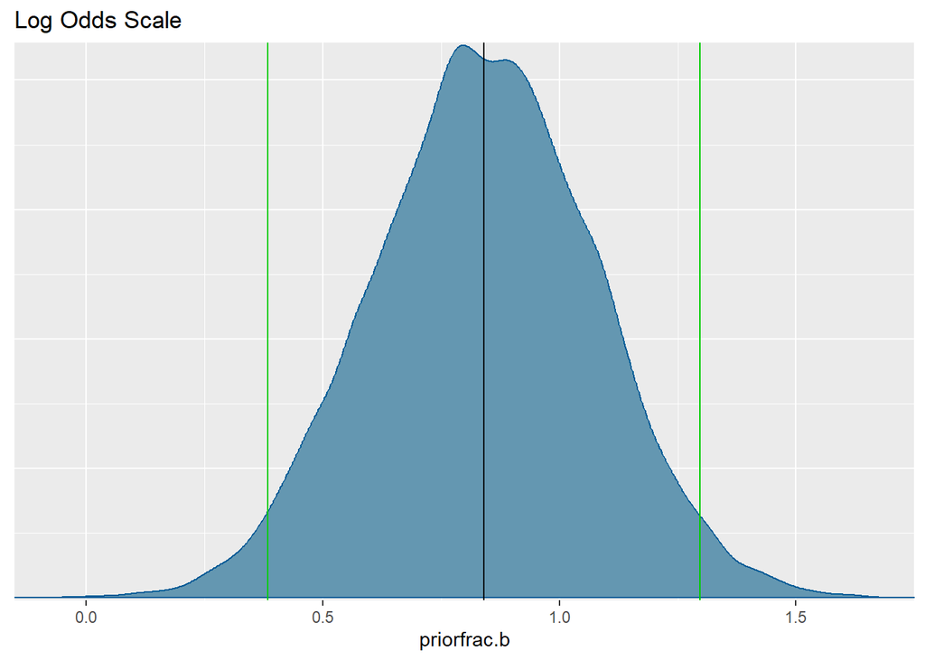

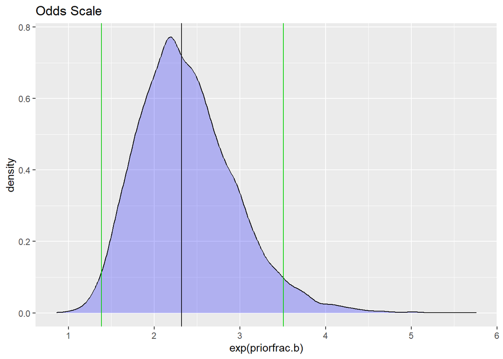

# Question 5: Evaluating Interaction Between Age and a Prior History of Fracture

## Write the Data Model

Write the data model. Use a similar format to what you used to write the data model in question 1. In your notation, use $\beta_0$, $\beta_1$, and $\beta_2$ as the intercept, prior history of fracture, and age respectively and explain what each parameter means. Remember, rstanarm gives model results without centering (even though the prior for the intercept is based on the other predictors being centered; see the next question).

The data model including the interaction term is as follows:

$ln[\frac{\pi_i}{1 - \pi_i}] = \beta_0 + \beta_1 X_{i1} + \beta_2 Age_{i1} + \beta_3 Age_{i1} X_{i1}$

## Prior Distributions for the Regression Parameters

Create an MCMC simulation of weakly informative priors for a model that includes prior history of fracture and age as covariates, as well as the interaction between these two factors. Write the priors that rstanarm has identified. **Use adjsuted priors from output -> will be 2.5 * 1 / sd(age)**

```
## Priors for model 'mod'
## ------
## Intercept (after predictors centered)
##  ~ normal(location = 0, scale = 2.5)
##
## Coefficients
##   Specified prior:
##     ~ normal(location = [0,0,0], scale = [2.5,2.5,2.5])
##   Adjusted prior:
##     ~ normal(location = [0,0,0], scale = [5.752,0.278,0.078])
## ------
## See help('prior_summary.stanreg') for more details
```

```
##   (Intercept)         priorfrac.b              age
##  Min.   :-80.25936   Min.   :-22.907168   Min.   :-1.029662
##  1st Qu.:-13.31731   1st Qu.: -3.817677   1st Qu.:-0.189552
##  Median : -0.21462   Median : -0.001070   Median : 0.002507
##  Mean   : -0.06366   Mean   :  0.001141   Mean   : 0.001102
##  3rd Qu.: 13.15774   3rd Qu.:  3.787412   3rd Qu.: 0.193540
##  Max.   : 71.73810   Max.   : 24.488221   Max.   : 1.141835
##  priorfrac.b:age
##  Min.   :-0.3125335
##  1st Qu.:-0.0524056
##  Median : 0.0002804
##  Mean   : 0.0003981
##  3rd Qu.: 0.0526989
##  Max.   : 0.3092918
```

## Posterior

Now update the priors with the data in the OSTEO dataset. Plot the posterior distribution for the interaction term and interpret the median and 95% highest posterior density credible interval. What impact does older age have on the relationship between fracture risk in those with and without prior history?

Write a single sentence that summarizes the strength of evidence you have that age interacts with prior history of fracture to increase the risk of fracture 1 year after diagnosis with osteoporosis?

```
## stan_glm
##  family:       binomial [logit]
##  formula:      fracture.b ~ priorfrac.b * age
##  observations: 500
##  predictors:   4
## ------
##                 Median MAD_SD
## (Intercept)     -5.416  1.038
## priorfrac.b      4.176  1.655
## age              0.059  0.015
## priorfrac.b:age -0.046  0.023
##
## ------
## * For help interpreting the printed output see ?print.stanreg
## * For info on the priors used see ?prior_summary.stanreg
```

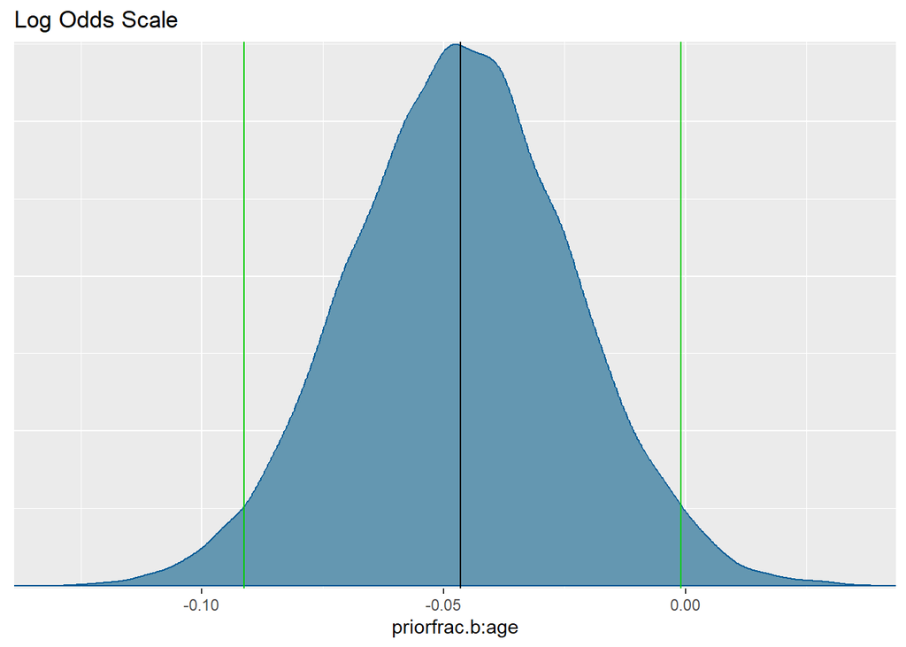

Most of the confidence interval is one one side of zero, so we can say that there is strong evidence of an interaction between age and prior history of fracture.

# Question 6: Predicting Fracture Risk Based on Prior History and Age

Make a plot that shows the posterior predicted probability of fracture at 1 year post-diagnosis with osteoporosis by age at diagnosis (55 to 80 years, in increments of 5 years) and prior history of fracture. HINT: Your plot should show the age at diagnosis on the X-axis and the posterior predicted probability on the Y axis. There should be two lines on the plot: one for women without a prior history of fracture and another for women who have a prior history of fracture.

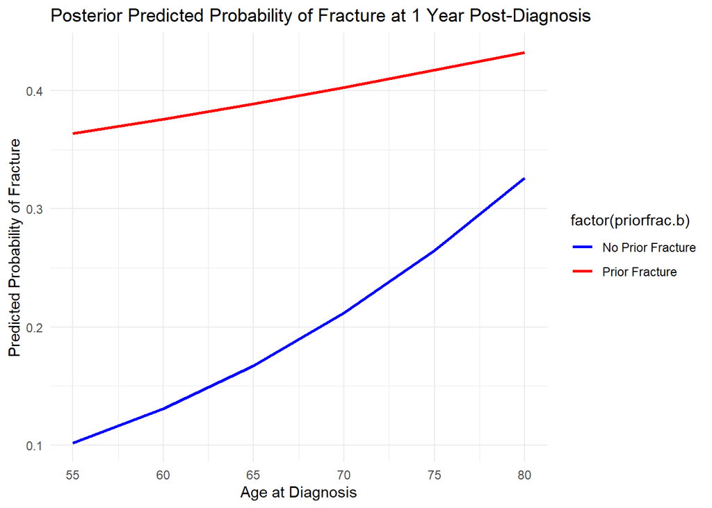

# Question 7: Posterior Predictive Check

Perform a posterior predictive check examining how consistent the model is with the original data. Use 100 datasets. Explain how this posterior predictive check works and what you conclude from the results.

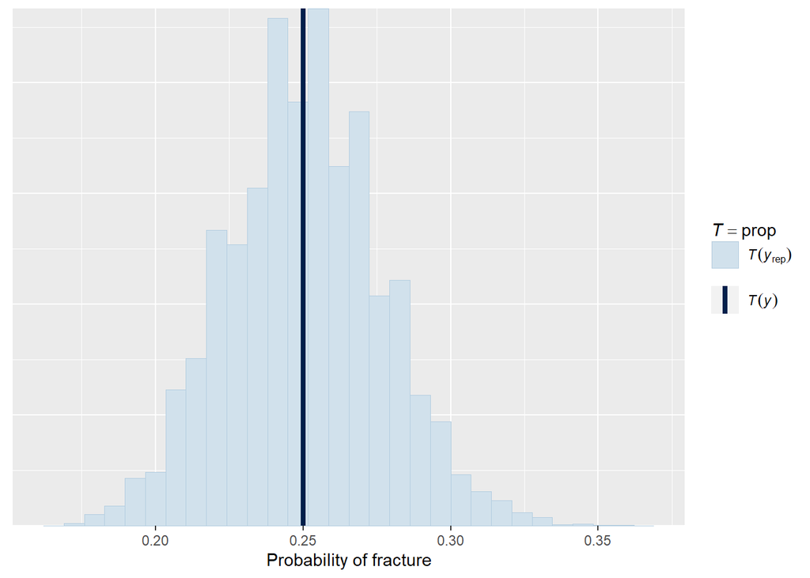

The posterior predictive check attempts to use our Bayesian model of the outcome to predict the outcome rate in our dataset via simulation. Because the observed fracture rate is roughly the median of the distribution of simulated fracture rates, we can conclude that our model is well-specified.

# Question 8: Identifying Women at High Risk of Fracture

Suppose that in clinical practice an intervention would be warranted in women who have a posterior predicted probability of fracture at 1 year that exceeds 40%. First, use this cutoff for predicting a woman is at high risk to evaluate the model based on the data you have. State the sensitivity, specificity, overall accuracy, and positive predictive value and interpret each of these in light of the clinical problem of identifying women eligible for an intervention to prevent fracture within 1 year of diagnosis with osteoporosis. HINT: rstanarm doesn’t give you the positive predictive value by default but you can use Bayes’ theorem to find positive predictive value based on sensitivity, specificity and prevalence.

Then, use cross validation to evaluate the future performance of the model. Again, state the sensitivity, specificity, overall accuracy, and positive predictive value and interpret each of these.